# Supervised learning competition

Authors

Aayush Sharma

Elli Rapti

Mansi Budamagunta

Nishant Rajamani

Petros Polychronopoulos

Published

October 21, 2025

```r
# Required packages (install if needed):
# install.packages(c("tidyverse", "GGally", "e1071", "skimr", "tree", "caret"))
```

# Introduction

In this assignment, we attempt to predict the exam scores for students based on other data about their school, family, social life etc. We begin by exploring the provided datasets using the principles of EDA. Then we preprocess the data to train predictions models on it. We train and analyse the results of the following models: multiple linear regression, support vector machines, and decision trees. We use 10-fold cross validation to compare the results of these models against each other and a trivial baseline. Then we use our best model to predict the exam scores on the test dataset.

# Data description

We begin by loading the data and looking at the variables present. Then we compute some summary statistics and check for missing values to understand the dataset better.

```r
# Load the training and test data
train <- readRDS("train.rds")
test <- readRDS("test.rds")

# Compute summary statistics
skim(train)
```

Data summary

| Name | train |
| --- | --- |
| Number of rows | 316 |
| Number of columns | 31 |
| _______________________ |  |
| Column type frequency: |  |
| factor | 17 |
| numeric | 14 |
| ________________________ |  |
| Group variables | None |

**Variable type: factor**

| skim_variable | n_missing | complete_rate | ordered | n_unique | top_counts |
| --- | --- | --- | --- | --- | --- |
| school | 0 | 1 | FALSE | 2 | GP: 276, MS: 40 |
| sex | 0 | 1 | FALSE | 2 | F: 173, M: 143 |
| address | 0 | 1 | FALSE | 2 | U: 246, R: 70 |
| famsize | 0 | 1 | FALSE | 2 | GT3: 224, LE3: 92 |
| Pstatus | 0 | 1 | FALSE | 2 | T: 282, A: 34 |
| Mjob | 0 | 1 | FALSE | 5 | oth: 116, ser: 83, at_: 48, tea: 41 |
| Fjob | 0 | 1 | FALSE | 5 | oth: 176, ser: 88, tea: 22, at_: 17 |
| reason | 0 | 1 | FALSE | 4 | cou: 116, hom: 88, rep: 82, oth: 30 |
| guardian | 0 | 1 | FALSE | 3 | mot: 214, fat: 72, oth: 30 |
| schoolsup | 0 | 1 | FALSE | 2 | no: 271, yes: 45 |
| famsup | 0 | 1 | FALSE | 2 | yes: 193, no: 123 |
| paid | 0 | 1 | FALSE | 2 | no: 178, yes: 138 |
| activities | 0 | 1 | FALSE | 2 | yes: 162, no: 154 |
| nursery | 0 | 1 | FALSE | 2 | yes: 248, no: 68 |
| higher | 0 | 1 | FALSE | 2 | yes: 298, no: 18 |
| internet | 0 | 1 | FALSE | 2 | yes: 257, no: 59 |
| romantic | 0 | 1 | FALSE | 2 | no: 213, yes: 103 |

**Variable type: numeric**

| skim_variable | n_missing | complete_rate | mean | sd | p0 | p25 | p50 | p75 | p100 | hist |
| --- | --- | --- | --- | --- | --- | --- | --- | --- | --- | --- |
| age | 0 | 1 | 16.75 | 1.30 | 15.00 | 16.00 | 17.00 | 18.00 | 22.00 | ▇▅▅▁▁ |
| Medu | 0 | 1 | 2.74 | 1.11 | 0.00 | 2.00 | 3.00 | 4.00 | 4.00 | ▁▅▆▆▇ |
| Fedu | 0 | 1 | 2.50 | 1.10 | 0.00 | 2.00 | 2.00 | 3.00 | 4.00 | ▁▆▇▇▇ |
| traveltime | 0 | 1 | 1.45 | 0.69 | 1.00 | 1.00 | 1.00 | 2.00 | 4.00 | ▇▃▁▁▁ |
| studytime | 0 | 1 | 2.03 | 0.84 | 1.00 | 1.00 | 2.00 | 2.00 | 4.00 | ▅▇▁▃▁ |
| failures | 0 | 1 | 0.37 | 0.79 | 0.00 | 0.00 | 0.00 | 0.00 | 3.00 | ▇▂▁▁▁ |
| famrel | 0 | 1 | 3.93 | 0.90 | 1.00 | 4.00 | 4.00 | 5.00 | 5.00 | ▁▁▃▇▅ |
| freetime | 0 | 1 | 3.22 | 0.97 | 1.00 | 3.00 | 3.00 | 4.00 | 5.00 | ▁▃▇▅▂ |
| goout | 0 | 1 | 3.07 | 1.10 | 1.00 | 2.00 | 3.00 | 4.00 | 5.00 | ▂▆▇▅▃ |
| Dalc | 0 | 1 | 1.47 | 0.88 | 1.00 | 1.00 | 1.00 | 2.00 | 5.00 | ▇▂▁▁▁ |
| Walc | 0 | 1 | 2.29 | 1.28 | 1.00 | 1.00 | 2.00 | 3.00 | 5.00 | ▇▅▅▂▂ |
| health | 0 | 1 | 3.47 | 1.39 | 1.00 | 3.00 | 3.50 | 5.00 | 5.00 | ▃▃▆▃▇ |
| absences | 0 | 1 | 5.72 | 8.30 | 0.00 | 0.00 | 4.00 | 8.00 | 75.00 | ▇▁▁▁▁ |
| score | 0 | 1 | -0.02 | 0.99 | -2.71 | -0.63 | -0.03 | 0.64 | 2.23 | ▁▃▇▇▂ |

We can see that the provided datasets do have the expected structure. The training data contains 316 rows and 31 columns. The test data contains 79 rows and 30 columns (all having the same type as training data, exluding the target variable). Of the 30 predictor variables, 17 are categorical and 13 numeric. There are no missing values in the training dataset.

Next we plot the distribution of the target variable (score):

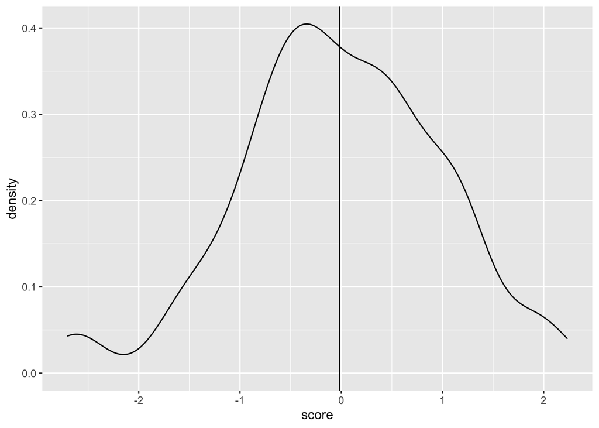

```r
# Plotting the mean and distribution of the score
ggplot(train, aes(score)) + geom_density() + geom_vline(xintercept =mean(train$score))
```

It’s roughly bell-shaped distribution, so the mean (also plotted) would be a good choice for a trivial baseline to compare more complex against.

We also compute the correlation matrix to get an idea of the relationships between the numeric variables. In particular, we are interested in the correlation of the predictor variables with the score, to get an intuition of which variables can have predictive power during training our models.

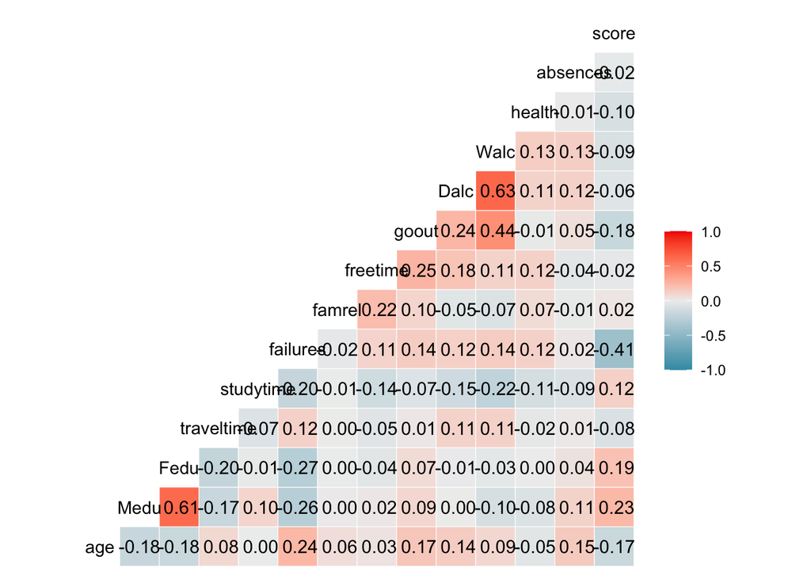

```r
# Correlation between numeric variables
ggcorr(train, label = TRUE, label_round = 2, type = "lower", stars=TRUE)
```

score – failures: seem to have strong correlation. We can see that the more failures they have, the score is lower. We plot a boxplot to explore this further.

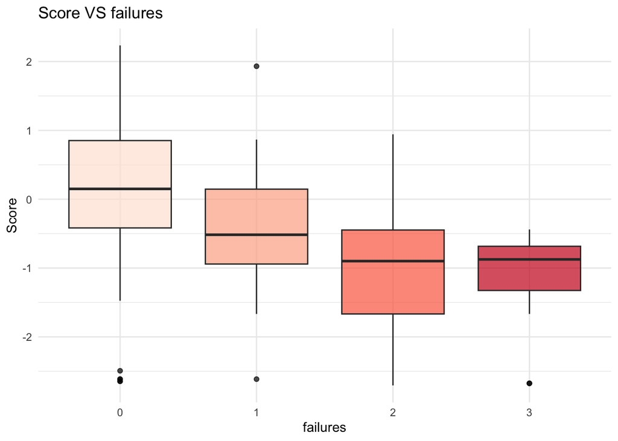

```r
# Failures vs score
ggplot(train, aes(x = as.factor(failures), y = score, fill = as.factor(failures))) +
  geom_boxplot(alpha = 0.7, outlier.color = "black") +
  scale_fill_brewer(palette = "Reds") +
  theme_minimal() +
  labs(
    title = "Score VS failures",
    x = "failures",
    y = "Score"
  ) +
  theme(legend.position = "none")
```

# Model description

We compare three different regression models to predict student exam scores: multiple linear regression, support vector machines (SVM), and decision trees. Multiple linear regression serves as our baseline parametric model, assuming a linear relationship between features and the target variable. It estimates coefficients for each predictor that minimize the squared difference between predicted and actual scores. This model is interpretable and computationally efficient, making it a natural starting point for regression tasks.

The other two models can capture non-linear relationships in the data. SVM with a radial basis function kernel maps the data to a higher-dimensional space where complex patterns become linearly separable. Decision trees partition the feature space through recursive splits based on feature values, creating interpretable rules but risking overfitting.

# Data transformation and pre-processing

```r
# Ensure categorical columns are factors
cat_cols <- names(train)[sapply(train, function(x) is.factor(x) || is.character(x))]
train[cat_cols] <- lapply(train[cat_cols], as.factor)

# one hot encoding
dv <- dummyVars(~ ., data = train, fullRank = TRUE)
train_encoded <- predict(dv, newdata = train)
train_encoded <- as.data.frame(train)
```

# Model comparison

We use 10-fold cross validation using the Mean Squared Error to compare models. We also compare the cross validated MSE of each model with the MSE obtained with the trivial baseline (mean) to check if the more completed models are learning any meaningful patterns from the predictor variables in the training data.

```r
# The function to compute MSE
mse <- function(y_true, y_pred) {mean((y_true - y_pred)^2)}

# Calculating MSE for the trivial baseline
mse_trivial <- mse(train$score, mean(train$score))

 #### Regression  ####
# Cross Validation function for regression
cv_lm <- function(formula, dataset, k) {
  # We can do some error checking before starting the function
  stopifnot(is_formula(formula))       # formula must be a formula
  stopifnot(is.data.frame(dataset))    # dataset must be data frame
  stopifnot(is.integer(as.integer(k))) # k must be convertible to int

  # first, add a selection column to the dataset as before
  n_samples  <- nrow(dataset)
  select_vec <- rep(1:k, length.out = n_samples)
  set.seed(123)
  data_split <- dataset %>% mutate(folds = sample(select_vec))

  # initialise an output vector of k mse values, which we
  # will fill by using a _for loop_ going over each fold
  mses <- rep(0, k)

  # start the for loop
  for (i in 1:k) {
    # split the data in train and validation set
    data_train <- data_split %>% filter(folds != i)
    data_valid <- data_split %>% filter(folds == i)

    # calculate the model on this data
    model_i <- lm(formula = formula, data = data_train)

    # Extract the y column name from the formula
    y_column_name <- as.character(formula)[2]

    # calculate the mean squared error and assign it to mses
    mses[i] <- mse(y_true = data_valid[[y_column_name]],
                   y_pred = predict(model_i, newdata = data_valid))
  }

  # now we have a vector of k mse values. All we need is to
  # return the mean mse!
  mean(mses)
}
mse_regression <- cv_lm(formula = score ~ ., dataset = train_encoded, k = 10)

#### SVM ####
#Cross validation with SVM
cv_svm <- function(formula, dataset, k) {
  # We can do some error checking before starting the function
  stopifnot(is_formula(formula))       # formula must be a formula
  stopifnot(is.data.frame(dataset))    # dataset must be data frame
  stopifnot(is.integer(as.integer(k))) # k must be convertible to int

  # first, add a selection column to the dataset as before
  n_samples  <- nrow(dataset)
  select_vec <- rep(1:k, length.out = n_samples)
  set.seed(123)
  data_split <- dataset %>% mutate(folds = sample(select_vec))

  # initialise an output vector of k mse values, which we
  # will fill by using a _for loop_ going over each fold
  mses <- rep(0, k)

  # start the for loop
  for (i in 1:k) {
    # split the data in train and validation set
    data_train <- data_split %>% filter(folds != i)
    data_valid <- data_split %>% filter(folds == i)

    # calculate the model on this data
    model_i <- svm(formula = formula, data = data_train)

    # Extract the y column name from the formula
    y_column_name <- as.character(formula)[2]

    # calculate the mean squared error and assign it to mses
    mses[i] <- mse(y_true = data_valid[[y_column_name]],
                   y_pred = predict(model_i, newdata = data_valid))
  }

  # return the mean mse
  mean(mses)
}
mse_svm <- cv_svm(score ~ ., dataset = train, k = 10)

#### Decison Trees ####
# Kfold cv that prunes inside each fold and evaluates mse on the held out fold,
# and records the best tree size selected per fold.
cv_tree_pruned <- function(formula, data, k = 10, seed = 1) {
  stopifnot(is_formula(formula))
  stopifnot(is.data.frame(data))
  stopifnot(is.integer(as.integer(k)))
  set.seed(seed)
  n <- nrow(data)
  folds <- sample(rep(1:k, length.out = n))
  y_name <- all.vars(formula)[1]
  #placeholders for mse and sizes
  fold_mse   <- numeric(k)
  best_sizes <- integer(k)

  for (i in seq_len(k)) {
    idx_train <- folds != i
    train_df  <- data[idx_train, , drop = FALSE]
    valid_df  <- data[!idx_train, , drop = FALSE]

    assign(".cvdata_fold", train_df, envir = .GlobalEnv)

    #tree on the fold's training split
    full <- tree(formula, data = .cvdata_fold)

    #Cross-validate within the training split to pick size
    cv  <- cv.tree(full)              # dev is rss for regression trees
    best_size <- cv$size[which.min(cv$dev)]
    best_sizes[i] <- best_size

    #Prune to the chosen size and evaluate on the folds validation split
    pruned <- prune.tree(full, best = best_size)
    pred   <- predict(pruned, newdata = valid_df)
    fold_mse[i] <- mean( (valid_df[[y_name]] - pred)^2 )
  }

  list(per_fold_mse = fold_mse,
       mean_mse     = mean(fold_mse),
       sd_mse       = sd(fold_mse),
       best_sizes   = best_sizes,
       chosen_size  = as.integer(median(best_sizes)))  #a stable single choice
}

#Running the function on the students data
cv_res <- cv_tree_pruned(score ~ ., train, k = 10, seed = 12)
mse_tree <- cv_res$mean_mse
best_tree_size  <- cv_res$chosen_size
```

# Chosen model - SVM

Below, we have listed the cross validated MSE we received for the 3 models analysed against the MSE for the trivial baseline. We see that SVM and decision tree perform better than multiple linear regression indicating that there is a non-linear relationship between the predictor variables and the target. All 3 models perform better than the trivial baseline. Since the MSE obtained for SVM and Decision trees are quite close, we choose SVM as our model as single decision trees tend to have a bias and may perform worse on test data.

```r
data.frame(
  model = c("Trivial Baseline (Mean)", "Multiple Linear Regression", "SVM", "Decision Tree"),
  mse = c(mse_trivial, mse_regression, mse_svm, mse_tree)
)
```

| model | mse |
| --- | --- |
| Trivial Baseline (Mean) | 0.9695311 |
| Multiple Linear Regression | 0.8826330 |
| SVM | 0.8193864 |
| Decision Tree | 0.8172408 |

```r
# Predicting scores for the test dataset

# train SVM on the training data
svm_mod <- svm(score ~ ., data = train, kernel = "radial")

# Predict on test set and save the file
predictions <- predict(svm_mod, test)
saveRDS(as.numeric(predictions), "predictions.rds")
```

# Team member contributions

- Aayush Sharma: Training and analysis of Decision Trees
- Elli Rapti: Training and analysis of Multiple Linear Regression
- Mansi Budamagunta: Compiling results and writing conclusion
- Nishant Rajamani: Exploratory data analysis and writing the report
- Petros Polychronopoulos: Training and analysis of SVM